# Hito 1: Estudio, análisis y pre-procesamiento de ataques terroristas en el mundo.

**Profesores:**

- Felipe Bravo-Marquez M.
- Hernán Sarmiento A.

**Auxiliares:**

- Jorge Ortiz F.
- Cinthia Sánchez M.

**Fecha:** 13 de Abril, 2022

**Nombres:**

- Augusto Aguayo B.
- Nicolás Brandstetter N.
- Nicolás Isla F.
- Sebastián Moreno M.
- Jordan Pérez D.

## Introducción

### Contexto

El terrorismo es algo que lamentablemente ha estado en nuestra sociedad desde hace décadas. Se define terrorismo como el uso sistemático del terror usado por distintas organizaciones o individuos con el fin de promocionar sus objetivos, ya sean políticos, económicos, religiosos o personales entre otros. Día a día se escuchan noticias referidas al tema en distintos lados del mundo, por lo que es interesante tener a disposición el registro histórico de estos eventos. Su estudio ayudaría a descubrir patrones de comportamientos o encontrar nueva información sobre eventos pasados para aprender de ellos, con la motivación de poder mejorar políticas de prevención de estos sucesos, que muchas veces significan pérdidas de vidas, destrucción de infraestructura, flora y/o fauna.

### Motivación

La principal motivación que lleva a escoger y estudiar este Data Set es encontrar y comprender patrones existentes en los ataques terroristas, visualizar la evolución de estos a lo largo de los años y encontrar tendencias y por ultimo, estudiar las implicancias existentes en los ataques terroristas, ya sea economica, política y socialmente. Esto dado que al tener mas información de esto, se podrían establecer protocolos de prevención.

## Limpieza del dataset

El dataset original, descargado de [Global Terrorism Database](https://www.start.umd.edu/gtd/), fue convertido a CSV mediante el siguiente script:

```python
import pandas as pd
#df_original = pd.read_excel('globalterrorismdb_0221dist.xlsx')
#df_original.to_csv('globalterrorismdb_0221dist.csv', index=False)
```

Para luego ser leído como:

```python
df = pd.read_csv('globalterrorismdb_0221dist.csv', low_memory=False)
```

Una vez cargado, se limpian los datos:

Eliminando las columnas que no interesan para el estudio:

```python
# Remove irrelevant columns for the study
to_remove = [
                'approxdate',                                                                           # Estimated date of the incident, when it is not certain.
                'country', 'region',                                                                    # Codes for country and region.
                'summary',                                                                              # Descriptive text about the incident.
                'doubtterr',                                                                            # Flags if there is doubt about this being a terrorist attack.
                'alternative', 'alternative_txt',                                                       # If there was doubt (doubtterr flag), proposes an alternative.
                'multiple',                                                                             # If corresponds with a series of related incidents, redundant with information in 'related' column.
                'attacktype1', 'attacktype2', 'attacktype3',                                            # Codes for attack types.
                'targtype1', 'targsubtype1',                                                            # Codes for target type in target 1.
                'target1',                                                                              # Descriptive text for target 1.
                'natlty1',                                                                              # Codes for nationality of target 1.
                'targtype2', 'targsubtype2',                                                            # Applies the same last 3 lines for target 2 and 3.
                'target2',
                'natlty2',
                'targtype3', 'targsubtype3',
                'target3',
                'natlty3',
                'gsubname', 'gsubname2', 'gsubname3',                                                   # Subdivision of group 1, 2 o 3 that has claimed the incident.
                'guncertain1', 'guncertain2', 'guncertain3',                                            # Flags if theres uncertainty about group 1, 2 or 3 taking part in the incident.
                'individual',                                                                           # Flags if the perpetrators do not correspond to a terrorist group, redudant by 'gname' column.
                'nperps',                                                                               # Number of perpetrators.
                'claimed', 'claimmode', 'claimmode_txt',                                                # Flags and codes/descriptive text about group 1 claiming the incident.
                'claim2', 'claimmode2', 'claimmode2_txt',                                               # Same for group 2 and 3.
                'claim3', 'claimmode3', 'claimmode3_txt',
                'compclaim',                                                                            # Flags if several groups claims the incident.
                'weaptype1', 'weapsubtype1',                                                            # Codes for weapon 1 type used by the perpetrators, below are codes for weapon 2, 3 and 4.
                'weaptype2', 'weapsubtype2',
                'weaptype3', 'weapsubtype3',
                'weaptype4', 'weapsubtype4',
                'weapdetail',                                                                           # Descriptive text about the weapons used by the perpetrators.
                'nkillus',  'nwoundus',                                                                 # Death and wounded toll, only taking US citizens into account.
                'propvalue', 'propcomment',                                                             # Damage to properties in USD (present in only few cases), and descriptive text about the damage.
                'nhostkidus',                                                                           # Number of hostages taken, only taking US citizens into account.
                'divert',                                                                               # Country that the kidnappers diverted after the resolution of the incident.
                'kidhijcountry',                                                                        # Country where the hostage incident was resolved.
                'ransom', 'ransomamt', 'ransomamtus', 'ransompaid', 'ransompaidus', 'ransomnote',       # Information about the ransom involving the hostage incident.
                'hostkidoutcome',                                                                       # Code for the outcome of the hostages.
                'addnotes',                                                                             # Descriptive text for additional notes about the incident.
                'scite1', 'scite2', 'scite3', 'dbsource',                                               # Information sources for the incident.
                'INT_MISC', 'INT_ANY',                                                                  # Flags if the incidents corresponds to an International misc. or any International type.
            ]

df = df.loc[:, ~df.columns.isin(to_remove)]
```

Luego, solo se consideran los incidentes ocurridos desde 1998 en adelante, puesto que desde este año se incluyen sistemáticamente muchos atributos en el dataset, e involucra tendencias actuales del terrorismo.

También, se remueven entradas que tengan mal formateada la fecha.

```python
# Remove incidents: 1.  Ocurred before 1998
#                   2.  With day/month set as 0
df = df[(df.iyear >= 1998) & (df.iday > 0) & (df.imonth > 0)]
```

Se remueven incidentes ocurridos en contextos de guerra, puesto que no son parte del foco de este estudio.

```python
# Remove incidents ocurred within context of war
df = df[df.crit3 != 0]
df = df.loc[:, df.columns!='crit3']
```

Se agrega según las columnas de año, mes y día (`iyear`, `imonth` y `iday` respectivamente) una columna `timestamp`, que indica la fecha de inicio del incidente.

También, según la columna `extended` y `resolution`, se agrega una columna `end_date`, que contiene la fecha de termino del incidente.

```python
import datetime
import numpy as np

# Merge iyear, imonth, iday column into a timestamp column within a timestamp format
df['timestamp'] = df[['iyear', 'imonth', 'iday']].apply(lambda s: datetime.datetime(*s), axis=1)
df = df.loc[:, ~df.columns.isin(['iyear', 'imonth', 'iday'])]

# Merge extended, resolution columns into end_date and duration (days) column
end_date  = pd.to_datetime(df['resolution'], format='%Y-%m-%d')
end_date = np.where(pd.isnull(df['resolution']), df['timestamp'], end_date)
df['end_date'] = end_date
df['duration'] = (df['end_date'] - df['timestamp']).apply(lambda s: s.days + 1)
df = df.loc[:, ~df.columns.isin(['extended', 'resolution'])]

# Filter out incidents where duration has a non positive value
df = df[df.duration > 0]
```

Se agrega una columna `perpcapture` según la columna `nperpcap`, que indica la captura de perpetradores del incidente, donde:

- `na`: No hay información de capturas.
- `1`: Hubieron perpetradores capturados.
- `0`: No hubieron perpetradores capturados.

```python
# Add a new column: perpcapture that flags when there are captured perpetrators
# where:    na. unknown
#            0. no perpetrator captured
#            1. at least one perpetrator captured
perpcapture = np.where(df.nperpcap == 0, 0, np.nan)
perpcapture = np.where(df.nperpcap > 0, 1, perpcapture)
df['perpcapture'] = perpcapture
df = df.loc[:, df.columns!='nperpcap']
```

Se agrega una columna `propdamage` según los datos de las columnas `property`, `propextent` y `propextent_txt`, que indica el daño a propiedades generado por el incidente, donde:

- `na`: No hay información de daño a propiedades.
- `0`: No hubo daños.
- `1`: Daños menores (costos $<$ 1 millón de USD)
- `2`: Daños mayores (1 millón $\leq$ costos $<$ 1000 millones de USD)
- `3`: Daños catastróficos (1000 millones de USD $\leq$ costos)

```python
df['propdamage'] = np.where(df.property == 0, 0, np.nan)
df['propdamage'] = np.where(df.propextent == 4, np.nan, df.propdamage)
df['propdamage'] = np.where(df.propextent == 3, 1, df.propdamage)
df['propdamage'] = np.where(df.propextent == 2, 2, df.propdamage)
df['propdamage'] = np.where(df.propextent == 1, 3, df.propdamage)
df = df.loc[:, ~df.columns.isin(['property', 'propextent', 'propextent_txt'])]
```

Reseteo de índices y se borra la columna creada `index`, que contiene los índices antiguos.

```python
# Reset indexes and delete the newly generated index column, containing the old indexes
df = df.reset_index()
df = df.loc[:, df.columns!='index']
```

Se eliminan las referencias a incidentes que han sido eliminados del dataset, y se agrega una columna `n_related` que indica cuantos incidentes relacionados hay para cada uno.

```python
# Ugly code to remove deleted references from related column
for i in range(len(df)):
    related_incidents_str = df.at[i, 'related']
    if pd.isna(related_incidents_str):
        df.at[i, 'related'] = ''
    else:
        related_incidents_initial = [int(event_id) for event_id in related_incidents_str.replace(' ', '').split(',')]

        related_incidents_final = []
        for event_id in related_incidents_initial:
            if event_id in df.eventid.values:
                related_incidents_final.append(event_id)

        df.at[i, 'related'] = ",".join([str(i) for i in related_incidents_final])


# Add a n_related column, displaying how many related incidents for each incident there are
n_related = np.where(df.related != '', df.related.apply(lambda s: len(s.split(','))), 0)
df['n_related'] = n_related

# Change blank values in related for nan
df.related = np.where(df.related == '', np.nan, df.related)
```

Reemplazo de los valores desconocidos por `na`.

```python
# Replace unknown values for n/a
columns_with_unknown_values = {
                                -9:         [
                                                'vicinity',
                                                'ishostkid', 'nhours',
                                                'INT_LOG', 'INT_IDEO'
                                            ],
                                -99:        [
                                                'nhostkid', 'nhours','ndays', 'nreleased'

                                            ],
                                'Unknown':  [
                                                'attacktype1_txt', 'attacktype2_txt', 'attacktype3_txt',
                                                'targtype1_txt', 'targtype2_txt', 'targtype3_txt',
                                                'gname',
                                                'motive',
                                                'weaptype1_txt', 'weaptype2_txt', 'weaptype3_txt', 'weaptype4_txt',
                                                'hostkidoutcome_txt'
                                            ]
                              }

for value in columns_with_unknown_values.keys():
    for column in columns_with_unknown_values[value]:
        df[column] = np.where(df[column] == value, np.nan, df[column])
```

Se agrega una columna `country_code` que indica el código del país en formato [ISO-3166-1](https://en.wikipedia.org/wiki/ISO_3166-1_alpha-3) , el cual será util para algunas librerías para graficar mapas.

```python
import pycountry

# Add an ISO-3166-1 column with 3-letter country code for each entry, used to plot maps in certain libraries.
def search_country_code(country_name):
    try:
        return pycountry.countries.search_fuzzy(country_name)[0].alpha_3
    except:
        return 'UNK'

country_code_dict = {country:search_country_code(country) for country in df.country_txt.unique()}
df['country_code'] = df.country_txt.apply(lambda c: country_code_dict[c])
```

Reordenación las columnas del dataset.

```python
# Reorder columns
column_order = [
                    'eventid',
                    'timestamp', 'end_date', 'duration',
                    'country_txt', 'country_code', 'region_txt', 'provstate', 'city', 'location',
                    'latitude', 'longitude', 'specificity', 'vicinity',
                    'crit1', 'crit2',
                    'success', 'suicide',
                    'attacktype1_txt', 'attacktype2_txt', 'attacktype3_txt',
                    'targtype1_txt', 'targsubtype1_txt', 'corp1', 'natlty1_txt',
                    'targtype2_txt', 'targsubtype2_txt', 'corp2', 'natlty2_txt',
                    'targtype3_txt', 'targsubtype3_txt', 'corp3', 'natlty3_txt',
                    'gname', 'gname2', 'gname3',
                    'motive',
                    'weaptype1_txt', 'weapsubtype1_txt',
                    'weaptype2_txt', 'weapsubtype2_txt',
                    'weaptype3_txt', 'weapsubtype3_txt',
                    'weaptype4_txt', 'weapsubtype4_txt',
                    'nkill', 'nkillter', 'nwound', 'nwoundte', 'perpcapture',
                    'ishostkid', 'nhostkid', 'nhours', 'ndays', 'hostkidoutcome_txt', 'nreleased',
                    'propdamage',
                    'INT_LOG', 'INT_IDEO',
                    'related', 'n_related'
               ]

df = df.reindex(columns=column_order)
```

Finalmente, se guarda el dataset ya limpio en un archivo `out.csv`.

```python
# Save the cleaned dataframe
#df.to_csv('out.csv', index=False, na_rep=np.nan)
```

## Exploración de datos

```python
import pandas as pd

#Numero de filas y columnas
#cantidad de instancias y atributos del Dataframe
print("El dataFrame posee:",df.shape[0],"instancias y",df.shape[1],"Atributos")
```

```
El dataFrame posee: 115997 instancias y 61 Atributos
```

Para una visualización más clara, se subdividió los atributos en dos grupos, de tal forma de ver sus medidas de tendencia central más cómodas.

```python
#Medidas de tendencia central para atributos
df.loc[:, ~df.columns.isin(['eventid', 'latitude', 'longitude'])].describe()
```

|  | duration | specificity | vicinity | crit1 | crit2 | success | suicide | nkill | nkillter | nwound | ... | perpcapture | ishostkid | nhostkid | nhours | ndays | nreleased | propdamage | INT_LOG | INT_IDEO | n_related |
| --- | --- | --- | --- | --- | --- | --- | --- | --- | --- | --- | --- | --- | --- | --- | --- | --- | --- | --- | --- | --- | --- |
| count | 115997.000000 | 115997.000000 | 115964.000000 | 115997.000000 | 115997.000000 | 115997.000000 | 115997.000000 | 111598.000000 | 113728.000000 | 107652.000000 | ... | 111804.000000 | 115594.000000 | 10245.000000 | 508.000000 | 2976.000000 | 6433.000000 | 84549.000000 | 50068.000000 | 50048.000000 | 115997.000000 |
| mean | 2.313353 | 1.457719 | 0.078197 | 0.987491 | 0.994508 | 0.871333 | 0.051398 | 2.378430 | 0.378825 | 3.791606 | ... | 0.038004 | 0.094270 | 10.562616 | 4.699311 | 48.349462 | 6.633919 | 0.441484 | 0.074978 | 0.287964 | 0.973258 |
| std | 27.391763 | 0.900207 | 0.268482 | 0.111142 | 0.073901 | 0.334833 | 0.220809 | 11.094821 | 3.557791 | 50.664405 | ... | 0.191207 | 0.292205 | 81.131921 | 5.487413 | 158.852977 | 53.744954 | 0.511237 | 0.263359 | 0.452819 | 4.128823 |
| min | 1.000000 | 1.000000 | 0.000000 | 0.000000 | 0.000000 | 0.000000 | 0.000000 | 0.000000 | 0.000000 | 0.000000 | ... | 0.000000 | 0.000000 | 0.000000 | 0.000000 | 0.000000 | 0.000000 | 0.000000 | 0.000000 | 0.000000 | 0.000000 |
| 25% | 1.000000 | 1.000000 | 0.000000 | 1.000000 | 1.000000 | 1.000000 | 0.000000 | 0.000000 | 0.000000 | 0.000000 | ... | 0.000000 | 0.000000 | 1.000000 | 1.000000 | 2.000000 | 0.000000 | 0.000000 | 0.000000 | 0.000000 | 0.000000 |
| 50% | 1.000000 | 1.000000 | 0.000000 | 1.000000 | 1.000000 | 1.000000 | 0.000000 | 1.000000 | 0.000000 | 0.000000 | ... | 0.000000 | 0.000000 | 2.000000 | 2.000000 | 5.000000 | 1.000000 | 0.000000 | 0.000000 | 0.000000 | 0.000000 |
| 75% | 1.000000 | 1.000000 | 0.000000 | 1.000000 | 1.000000 | 1.000000 | 0.000000 | 2.000000 | 0.000000 | 3.000000 | ... | 0.000000 | 0.000000 | 5.000000 | 6.000000 | 21.000000 | 3.000000 | 1.000000 | 0.000000 | 1.000000 | 0.000000 |
| max | 2677.000000 | 5.000000 | 1.000000 | 1.000000 | 1.000000 | 1.000000 | 1.000000 | 1385.000000 | 500.000000 | 10878.000000 | ... | 1.000000 | 1.000000 | 5350.000000 | 24.000000 | 2676.000000 | 2958.000000 | 3.000000 | 1.000000 | 1.000000 | 80.000000 |

8 rows × 21 columns

La mediana, es un dato que juega un rol fundamental cuando más adelante, se tengan que hacer estimaciones considerando grandes volumenes de dato, esto pues, a diferencia de la media, es menos propensa a variar en presencia de outliers.

```python
df.median()
```

```
eventid        2.014043e+11
duration       1.000000e+00
latitude       3.217462e+01
longitude      4.468522e+01
specificity    1.000000e+00
vicinity       0.000000e+00
crit1          1.000000e+00
crit2          1.000000e+00
success        1.000000e+00
suicide        0.000000e+00
nkill          1.000000e+00
nkillter       0.000000e+00
nwound         0.000000e+00
nwoundte       0.000000e+00
perpcapture    0.000000e+00
ishostkid      0.000000e+00
nhostkid       2.000000e+00
nhours         2.000000e+00
ndays          5.000000e+00
nreleased      1.000000e+00
propdamage     0.000000e+00
INT_LOG        0.000000e+00
INT_IDEO       0.000000e+00
n_related      0.000000e+00
dtype: float64
```

Es importante considerar de los resultados anteriores que no todas las medidas de tendencia central son importantes de estudiar. Por ejemplo, no tiene mayor utilidad saber la media aritmética de la longitud o latitud, pero sí tiene sentido saber que la duración promedio de los atentados terroristas es de 2.3 días aproximadamente, por dicho motivo, se filtraron ciertas columnas a la hora de ver las medidas de tendencia central. \

Otra cosa importante que se exploró fueron la cantidad de Na que existen en el DataFrame. En la limpieza de este se reemplazaron todos los valores en blancos y valores que representaban una falta de información (como -1,-9,-99, na etc) y se transformaron en valores Na. Así, se obtuvieron los siguientes valores

```python
#Cantidad de NA en cada atributo del dataFrame
sumNA=df.isna().sum()
sumNA
```

```
eventid            0
timestamp          0
end_date           0
duration           0
country_txt        0
               ...
propdamage     31448
INT_LOG        65929
INT_IDEO       65949
related        96789
n_related          0
Length: 61, dtype: int64
```

Para tener una idea inicial de las relaciones que existen entre los diferentes atributos, se genera la matriz de correlación entre todos los atributos del dataset.

```python
Matriz_correlacion=df[[x for x in NumsColumns if x not in ['eventid','latitude','longitude']]].corr()
Matriz_correlacion
```

|  | duration | specificity | vicinity | crit1 | crit2 | success | suicide | nkill | nkillter | nwound | ... | perpcapture | ishostkid | nhostkid | nhours | ndays | nreleased | propdamage | INT_LOG | INT_IDEO | n_related |
| --- | --- | --- | --- | --- | --- | --- | --- | --- | --- | --- | --- | --- | --- | --- | --- | --- | --- | --- | --- | --- | --- |
| duration | 1.000000 | 0.016096 | 0.008562 | -0.003291 | -0.002953 | 0.018332 | -0.011104 | -0.006076 | -0.004552 | -0.003035 | ... | -0.000942 | 0.147459 | -0.003526 | -0.034181 | 0.870349 | -0.007852 | -0.037079 | 0.005605 | 0.043591 | -0.010182 |
| specificity | 0.016096 | 1.000000 | -0.078167 | 0.016729 | -0.003296 | -0.010856 | -0.051521 | 0.000070 | 0.028793 | -0.017767 | ... | -0.036310 | 0.080078 | -0.009674 | 0.060130 | -0.000218 | -0.014513 | -0.061242 | -0.032690 | -0.056776 | 0.015821 |
| vicinity | 0.008562 | -0.078167 | 1.000000 | 0.001557 | -0.002255 | -0.002677 | -0.007448 | -0.002783 | -0.007357 | -0.006245 | ... | -0.008724 | 0.023601 | -0.007193 | 0.015390 | 0.027441 | 0.001265 | -0.012206 | 0.018209 | 0.000090 | -0.025350 |
| crit1 | -0.003291 | 0.016729 | 0.001557 | 1.000000 | -0.008363 | -0.012671 | 0.023388 | 0.009444 | 0.008621 | 0.003992 | ... | -0.018663 | -0.017324 | 0.012947 | -0.011427 | -0.005012 | 0.012296 | 0.015311 | -0.012563 | 0.009453 | 0.021627 |
| crit2 | -0.002953 | -0.003296 | -0.002255 | -0.008363 | 1.000000 | -0.014271 | -0.014401 | -0.016175 | -0.005802 | -0.001077 | ... | 0.004318 | -0.010470 | 0.003795 | 0.013754 | -0.036861 | 0.010069 | 0.017833 | 0.004858 | -0.012837 | 0.007232 |
| success | 0.018332 | -0.010856 | -0.002677 | -0.012671 | -0.014271 | 1.000000 | -0.017128 | 0.062559 | -0.008711 | 0.025029 | ... | -0.095192 | 0.121220 | 0.003608 | 0.059399 | 0.007813 | 0.002713 | 0.273939 | -0.015723 | -0.020511 | 0.022112 |
| suicide | -0.011104 | -0.051521 | -0.007448 | 0.023388 | -0.014401 | -0.017128 | 1.000000 | 0.169723 | 0.103277 | 0.092789 | ... | 0.046724 | -0.061951 | 0.059720 | -0.011703 | -0.013117 | 0.052622 | 0.048079 | 0.012178 | 0.132070 | -0.013972 |
| nkill | -0.006076 | 0.000070 | -0.002783 | 0.009444 | -0.016175 | 0.062559 | 0.169723 | 1.000000 | 0.400462 | 0.704749 | ... | -0.007409 | 0.039233 | 0.399041 | -0.039176 | -0.019443 | 0.359714 | 0.056827 | -0.005736 | 0.059058 | -0.006917 |
| nkillter | -0.004552 | 0.028793 | -0.007357 | 0.008621 | -0.005802 | -0.008711 | 0.103277 | 0.400462 | 1.000000 | 0.040964 | ... | -0.001780 | -0.014525 | 0.123156 | 0.125693 | -0.017639 | 0.192119 | -0.034722 | -0.008599 | 0.024013 | -0.005630 |
| nwound | -0.003035 | -0.017767 | -0.006245 | 0.003992 | -0.001077 | 0.025029 | 0.092789 | 0.704749 | 0.040964 | 1.000000 | ... | 0.007339 | 0.003334 | 0.053507 | -0.042451 | -0.004353 | 0.026637 | 0.053926 | 0.000206 | 0.024954 | 0.002485 |
| nwoundte | -0.002867 | 0.051943 | -0.009675 | 0.006026 | -0.001427 | -0.004807 | -0.003045 | 0.178657 | 0.703759 | 0.026898 | ... | 0.007398 | -0.012844 | 0.007820 | 0.022936 | -0.006362 | 0.015359 | -0.036470 | -0.023715 | -0.035738 | -0.006646 |
| perpcapture | -0.000942 | -0.036310 | -0.008724 | -0.018663 | 0.004318 | -0.095192 | 0.046724 | -0.007409 | -0.001780 | 0.007339 | ... | 1.000000 | -0.021517 | 0.018033 | 0.039038 | 0.002890 | 0.043251 | -0.041761 | 0.043034 | 0.004394 | -0.005513 |
| ishostkid | 0.147459 | 0.080078 | 0.023601 | -0.017324 | -0.010470 | 0.121220 | -0.061951 | 0.039233 | -0.014525 | 0.003334 | ... | -0.021517 | 1.000000 | 0.002574 | NaN | NaN | -0.001060 | -0.191959 | 0.017457 | 0.041371 | -0.033410 |
| nhostkid | -0.003526 | -0.009674 | -0.007193 | 0.012947 | 0.003795 | 0.003608 | 0.059720 | 0.399041 | 0.123156 | 0.053507 | ... | 0.018033 | 0.002574 | 1.000000 | 0.099172 | -0.020154 | 0.946671 | 0.030878 | 0.013230 | 0.066215 | 0.023602 |
| nhours | -0.034181 | 0.060130 | 0.015390 | -0.011427 | 0.013754 | 0.059399 | -0.011703 | -0.039176 | 0.125693 | -0.042451 | ... | 0.039038 | NaN | 0.099172 | 1.000000 | -0.281461 | 0.116004 | -0.082228 | 0.033286 | 0.004351 | -0.056440 |
| ndays | 0.870349 | -0.000218 | 0.027441 | -0.005012 | -0.036861 | 0.007813 | -0.013117 | -0.019443 | -0.017639 | -0.004353 | ... | 0.002890 | NaN | -0.020154 | -0.281461 | 1.000000 | -0.019504 | -0.001988 | 0.064448 | 0.201493 | -0.025210 |
| nreleased | -0.007852 | -0.014513 | 0.001265 | 0.012296 | 0.010069 | 0.002713 | 0.052622 | 0.359714 | 0.192119 | 0.026637 | ... | 0.043251 | -0.001060 | 0.946671 | 0.116004 | -0.019504 | 1.000000 | 0.052892 | 0.023844 | 0.048932 | 0.006967 |
| propdamage | -0.037079 | -0.061242 | -0.012206 | 0.015311 | 0.017833 | 0.273939 | 0.048079 | 0.056827 | -0.034722 | 0.053926 | ... | -0.041761 | -0.191959 | 0.030878 | -0.082228 | -0.001988 | 0.052892 | 1.000000 | -0.001931 | -0.032246 | 0.076715 |
| INT_LOG | 0.005605 | -0.032690 | 0.018209 | -0.012563 | 0.004858 | -0.015723 | 0.012178 | -0.005736 | -0.008599 | 0.000206 | ... | 0.043034 | 0.017457 | 0.013230 | 0.033286 | 0.064448 | 0.023844 | -0.001931 | 1.000000 | 0.332459 | -0.039029 |
| INT_IDEO | 0.043591 | -0.056776 | 0.000090 | 0.009453 | -0.012837 | -0.020511 | 0.132070 | 0.059058 | 0.024013 | 0.024954 | ... | 0.004394 | 0.041371 | 0.066215 | 0.004351 | 0.201493 | 0.048932 | -0.032246 | 0.332459 | 1.000000 | 0.021361 |
| n_related | -0.010182 | 0.015821 | -0.025350 | 0.021627 | 0.007232 | 0.022112 | -0.013972 | -0.006917 | -0.005630 | 0.002485 | ... | -0.005513 | -0.033410 | 0.023602 | -0.056440 | -0.025210 | 0.006967 | 0.076715 | -0.039029 | 0.021361 | 1.000000 |

21 rows × 21 columns

De esta matriz se extraen las siguientes cosas:

Análisis como estos servirán en un futuro para generar predicciones y asociaciones no triviales en este dataset, pues aparte de describir que significa cada valor correlacional (lo que sería muy largo y poco productivo), permite usar dichos valores para por ejemplo, asociar un peso a un conjunto de atributos en una red neuronal destinada a hacer clasificaciones en este dataset, siendo un valor en principio oculto pero que sirva como ladrillo para generar una predicción bien fundamentada.

### Graficos

```python
df["country_txt"].value_counts().head(10)
```

```
Iraq           23728
Afghanistan    13785
Pakistan       12015
India          10032
Philippines     4877
Nigeria         4615
Yemen           4036
Thailand        3537
Somalia         3179
Colombia        2514
Name: country_txt, dtype: int64
```

Para poder visualizar la información anterior en primera instancia se hizo un gráfico simple haciendo uso de las latitudes y longitudes del dataset. El primer resultado se puede apreciar en la siguiente figura.

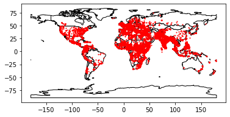

```python
import pandas as pd
import geopandas
#deben correr en otra celda un pip install geopandas para importar la librería
import matplotlib.pyplot as plt
from shapely.geometry import Point
long = df['longitude']
lat = df['latitude']
world = geopandas.read_file(geopandas.datasets.get_path('naturalearth_lowres'))
geometry = [Point(xy) for xy in zip(long,lat)]
base = world.plot(color='white', edgecolor='black')
geo_df = geopandas.GeoDataFrame(geometry = geometry)
geo_df.plot(ax=base, marker='o', color='red', markersize=1)
```

A continuación, se genera un *scatter plot* que marca con un punto cada incidente en el mapa:

```python
import plotly.express as px

fig = px.scatter_geo(df, lat=df.latitude, lon=df.longitude)
fig.write_html("scatter_geo_basico.html")
```

Es importante notar que este mapa realiza una carga importante sobre el sistema al renderizarlo, por lo que se recomienza luego de analizarlo cerrar u ocultar su celda.

```python
%%html
<iframe src="scatter_geo_basico.html" width="800" height="600" title="Choropleth map with plotly" style="border:none"></iframe>
```

[interactive chart not shown]

También, a partir de estos datos, se genera un *heatmap* mostrando los incidentes por país.

```python
import json

# GEOjson with country border data.
with open('countries.geojson', 'r') as fp:
    country_json = json.load(fp)

# Counts the number of incidents per country
df_count = df['country_txt'].value_counts(dropna=False).rename_axis('country').reset_index(name='count')
df_count['code'] = df_count.country.apply(lambda s: country_code_dict.get(s))

fig = px.choropleth(data_frame=df_count,
                    locations='code',
                    locationmode='ISO-3',
                    geojson=country_json,
                    color='count',
                    hover_name='count',
                    color_continuous_scale=px.colors.sequential.amp)

fig.write_html("heat_country_basico.html")
```

```python
from IPython.display import IFrame
IFrame(src='heat_country_basico.html', width=800, height=500)
```

[interactive chart not shown]

Es directo observar que en Irak y el subcontinente Indio junto con Afganistán y Pakistán es donde se concentra la mayor cantidad de incidentes a la fecha, por lo que se revisará en mas detalle las 10 subdivisiones administrativas (provincias en el caso de Irak) con mayor cantidad de ataques.

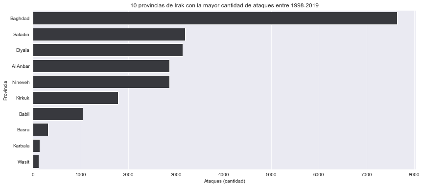

```python
df_iraq = df[df['country_txt'] == 'Iraq']
df_count_iraq = df_iraq['provstate'].value_counts(dropna=False).rename_axis('provstate').reset_index(name='count')

import seaborn as sns
import matplotlib.pyplot as plt

# Make a barplot
fig = plt.figure(figsize=(14, 6))
sns.set_style("darkgrid")
ax = sns.barplot(x="count", y="provstate",
                 data=df_count_iraq.nlargest(10, 'count'),
                 color='#37383fff',
                )

ax.set(xlabel='Ataques (cantidad)', ylabel='Provincia')
ax.set(title='10 provincias de Irak con la mayor cantidad de ataques entre 1998-2019');
```

A continuación, se estudia como ha cambiado en el tiempo la frecuencia de bombardeos o explosiones, normalizados en función de la cantidad total de actos terroristas ocurridos cada año.

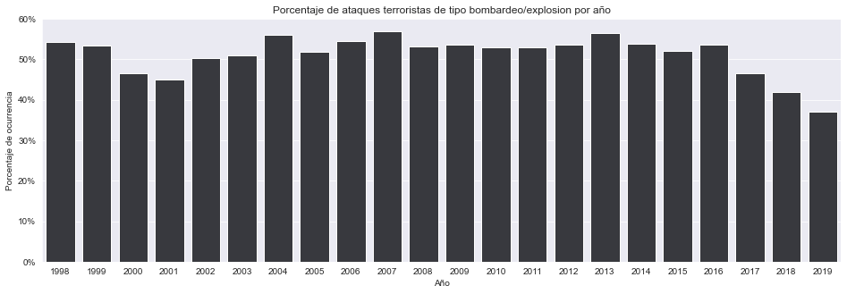

```python
df_bomb = df[df.attacktype1_txt == 'Bombing/Explosion']
df_bomb = df_bomb['timestamp'].apply(lambda s: s.year).value_counts(dropna=False).rename_axis('year').reset_index(name='frequency')


df_bomb['frequency'] = 100 * df_bomb['frequency'] / df['timestamp'].apply(lambda s: s.year).value_counts(dropna=False).rename_axis('year').reset_index(name='frequency')['frequency']
df_bomb = df_bomb.sort_values(by=['year'], ascending=True)

# Make a barplot
fig = plt.figure(figsize=(16, 5))
ax = sns.barplot(x="year", y="frequency",
                 data=df_bomb,
                 color='#37383fff'
                );


ax.set(xlabel='Año', ylabel='Porcentaje de ocurrencia');
ax.set(title='Porcentaje de ataques terroristas de tipo bombardeo/explosion por año');

ax.yaxis.set_ticks([int(x) for x in ax.get_yticks()])
ax.set_yticklabels([str(int(x)) + '%' for x in ax.get_yticks()]);
```

El siguiente gráfico muestra la cantidad de ataques terroristas por año en el mundo.

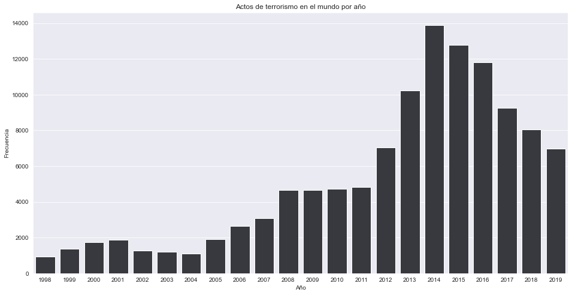

```python
df_attacks = df.groupby(df['timestamp'].apply(lambda s: s.year)).count()['eventid'].rename_axis('year').reset_index(name='frequency')

# Make a barplot
fig = plt.figure(figsize=(16, 8))
ax = sns.barplot(x="year", y="frequency",
                 data=df_attacks,
                 color='#37383fff'
                )

ax.set(xlabel='Año', ylabel='Frecuencia');
ax.set(title='Actos de terrorismo en el mundo por año');
```

Se observa que los actos terroristas durante los años 1998-2004 se mantienen en un rango conservado al rededor de los 1000-2000 por año, sin embargo en el 2005 comienzan a crecer, explosivamente desde el 2012 hasta un máximo en el 2014, alcanzando cercano a los 14000 actos durante todo el año, donde comienza a bajar dicha cantidad hasta el año 2019, donde acaba la muestra.

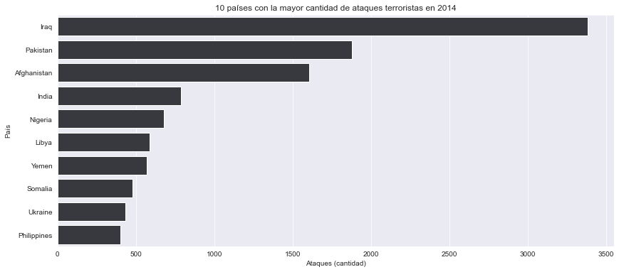

```python
df_2014 = df[df['timestamp'].apply(lambda s: s.year) == 2014].groupby('country_txt').count()['eventid'].rename_axis('country').reset_index(name='frequency')
df_2014 = df_2014.sort_values(by=['frequency'], ascending=False)

# Make a barplot
fig = plt.figure(figsize=(14, 6))
ax = sns.barplot(x="frequency", y="country",
                 data=df_2014.nlargest(10, 'frequency'),
                 color='#37383fff'
                )

ax.set(xlabel='Ataques (cantidad)', ylabel='País')
ax.set(title='10 países con la mayor cantidad de ataques terroristas en 2014');
```

A continuación, se estudia como la cantidad de ataques terroristas en estos 10 países evoluciona al pasar los años.

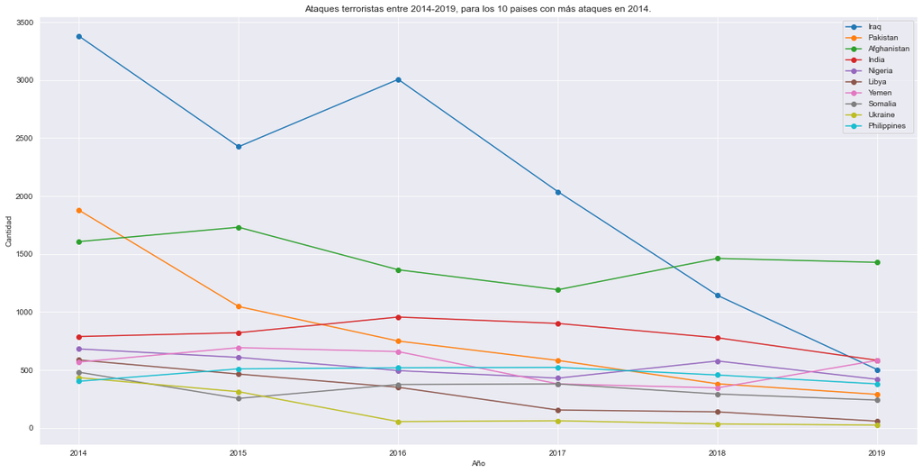

```python
countries = list(df_2014.nlargest(10, 'frequency')['country'])
df['year'] = df['timestamp'].apply(lambda s: s.year)

df_2014_2019 = pd.DataFrame()
df_2014_2019['year'] = range(2014, 2019+1)
for country in countries:
    country_series = df[(2014 <= df.year) & (df.country_txt == country)].groupby(df.year).count()['eventid'].reset_index(name='frequency')
    df_2014_2019[country] = country_series['frequency']

# Make connected scatter plot
df_2014_2019.plot(kind='line', x='year', y=countries,
                  backend='matplotlib',
                  style='o-', figsize=(20, 10),
                  xlabel='Año', ylabel='Cantidad',
                  title='Ataques terroristas entre 2014-2019, para los 10 paises con más ataques en 2014.');

df = df.loc[:, df.columns!='year']
```

Es posible observar también que estos 10 paises (a excepcion de Afganistán), terminan el 2019 con una cantidad de ataques entre 0 a 1000, cifra que se tiende a estabilizar a ese rango.

## Preguntas y problemas

Una vez viendo el panorama del dataset limpio y analizado, como grupo se generaron las siguientes preguntas e hipótesis que se estiman pueden ser respondidas y validadas con herramientas de minería de datos:

- ¿Se puede establecer un mapa de calor de donde se concentran los atentados terroristas? ¿Y cómo ha variado este en el tiempo?
- ¿Existe alguna relación referente a la tasa de éxito de estos atentados frente a alguna de las características de la base de datos?
- ¿Cómo han variado en el tiempo los ataques terroristas en cuanto armas/tipo de ataque/objetivos?
- ¿Es posible establecer alguna relación entre zonas geográficas y si el ataque es doméstico o internacional?
- ¿Es posible que un cierto grupo de atributos pertenecientes a una instancia tengan una alta correlación con el acierto de un ataque?
- ¿Existe alguna relación entre la zona del ataque y la fecha del atentado?
- ¿Hay algún tipo de relación entre la zona geográfica del ataque con el motivo de éste? (ejemplo, ataques con índole religioso con más frecuentes en ciertos sectores)
- ¿Es posible, con los datos actuales, encontrar zonas de sospecha de aumento de actos terroristas?
- Verificar las áreas de dominio de distintos grupos a escala global.
- Existe relación entre el pais y el tipo de acto terrorista que ha sufrido de manera mas frecuente?
- Patrón o tendencia de alguna nacionalidad en cometer ataques terristas sobre otro.
- Comportamiento del terrorismo a lo largo de los años.

Para el próximo hito se espera poder combinar este data set con algunas variables geopoliticas de los paises, como el sistema politico, el poder economico, las religiones e ideologías predominantes, hitos históricos que ocurrieron cercano al ataque terrorista, etc.

## Contribución por cada integrante

- Augusto Aguayo B.: Limpieza del dataset, confeccion de gráficos, creación de repositorio web, análisis inicial del dataset.
- Nicolás Brandstetter N.: Exploración de datos y redacción, edición de video, presentación, análisis inicial del dataset.
- Nicolás Isla F.: Presentación, análisis inicial del dataset, formulación de preguntas.
- Sebastián Moreno M.: Análisis inicial del dataset, formulación de preguntas.
- Jordan Pérez D.: Presentación, análisis inicial del dataset, redacción de Introduccion y Motivación, formulación de preguntas.